# MATH1318 - Time Series Analysis - Assignment 1

Samuel Holt

March 15, 2019

# Introduction

The dataset provided is of the yearly changes in thickness of the Ozone layer from 1927 to 2016 in Dobson units. A single data point per year is the percentage change in Dobson units compared to the previous year.

In this report I will be investigating if any deterministic trends exist in the time series data. This will include a linear model, a quadratic model, and a hybrid quadratic harmonic model. Each model will be evaluated in it’s p-values for the variables involved, the R squared value, and also its residuals. FOr the residuals of each respective model, normality will be investigated using histgrams, quantile-quantile plots and validated using the Shaprio-Wilks test. The autocorrelations of each lag of the residuals will also visualised using Auto Correlation Function plots, to investigate significant autocorrelative trends in the residuals of the model. Finally, I will forecast the following 5 years with each model, but propose the most statistically valid model to finalise forecast predictions for this report.

First, we set the working directory.

```r
setwd(
  "C:/Users/samgh/Desktop/Masters of Statistics and Operations Research/Year 2/Sem 1/Time Series Analysis/Assignments/Assignment 1"
)
```

Load appropriate packages.

```r
library(TSA)
library(dplyr)
```

## Import and Convert Data

Load data, no headers present in csv file, hence set header argument to FALSE.

```r
dataset <- read.csv('data1.csv', header = FALSE)
```

Convert dataframe to a time series object.

```r
data_ts <- ts(dataset,
              start = 1927,
              end = 2016,
              frequency = 1)
```

## Visualise Data

Visualise the time series data in order to gauge what models could be tested.

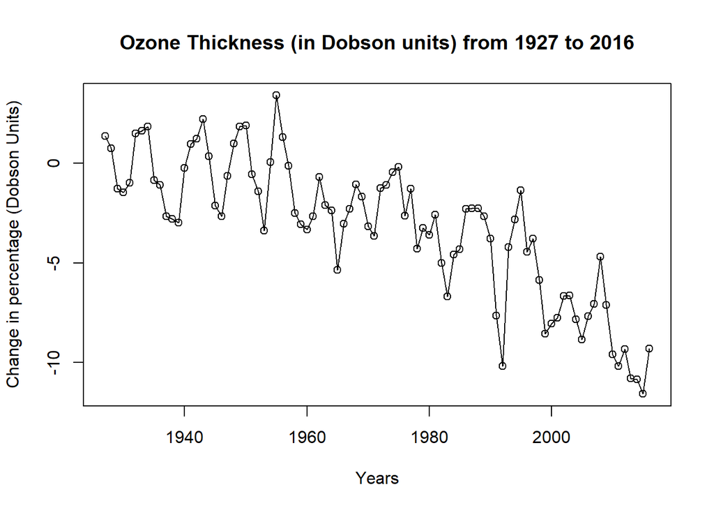

```r
plot(
  data_ts,
  xlab = 'Years',
  ylab = 'Change in percentage (Dobson Units)',
  type = 'o',
  main = 'Ozone Thickness (in Dobson units) from 1927 to 2016'
)
```

Demonstrated by the scatterplot, there is clearly a a downward trend.

Let’s investigate if the first lag holds any visual clues to a valid correlation.

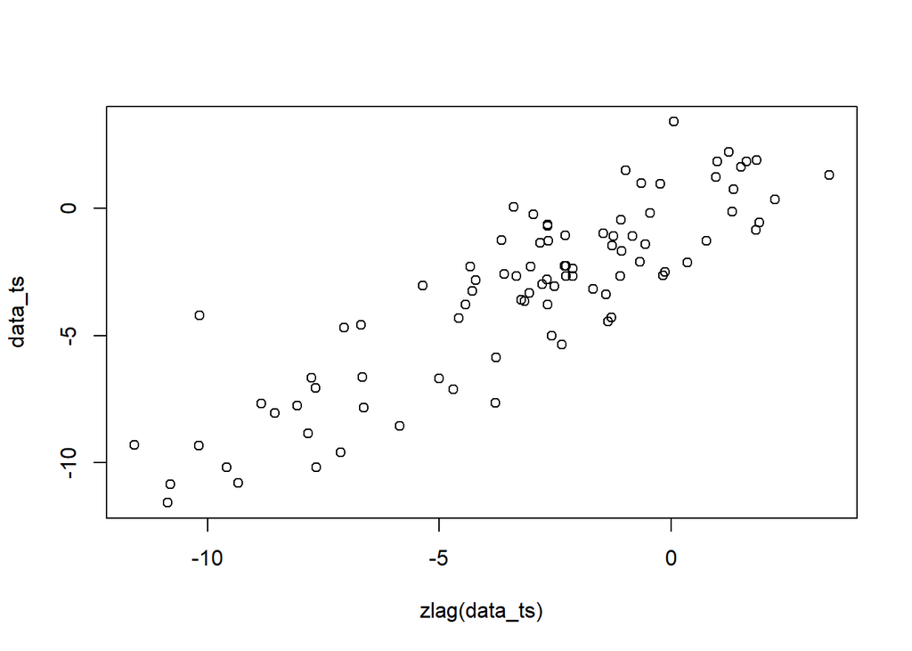

```r
plot(y = data_ts,
     x = zlag(data_ts))
```

A notable linear correlation is present with the given scatterplot, a single obvious outlier also present, but this shouldn’t cause any deviations.

Here I will determine the autocorrelation coefficient to see if there is any significant correlations with the original time series data.

```r
x <- data_ts
y <- zlag(data_ts)
index <- 2:length(x)
cor(x[index],
    y[index])
```

```
## [1] 0.8700381
```

An autocorrelation coefficient of 0.87 shows a significant correlation between the time series data and its first lag.

Given the evident trend in the original time series scatterplot, a linear model will be fit and investigated for statistical significance.

```r
# fit a linear regression model
t <- time(data_ts)
lin_model <- lm(data_ts ~ t)
summary(lin_model)
```

```
##
## Call:
## lm(formula = data_ts ~ t)
##
## Residuals:
##     Min      1Q  Median      3Q     Max
## -4.7165 -1.6687  0.0275  1.4726  4.7940
##
## Coefficients:
##               Estimate Std. Error t value Pr(>|t|)
## (Intercept) 213.720155  16.257158   13.15   <2e-16 ***
## t            -0.110029   0.008245  -13.34   <2e-16 ***
## ---
## Signif. codes:  0 '***' 0.001 '**' 0.01 '*' 0.05 '.' 0.1 ' ' 1
##
## Residual standard error: 2.032 on 88 degrees of freedom
## Multiple R-squared:  0.6693, Adjusted R-squared:  0.6655
## F-statistic: 178.1 on 1 and 88 DF,  p-value: < 2.2e-16
```

```r
# R^2: 0.67
```

Both coefficients, the intercept and time (t), have been shown to have statistical significance in regard to the dependent variable, Dobson Units by year. Also note an R squared value of 0.6693, which isn’t deemed as high, but certainly not insignificant.

Here we will plot the linear model against the time series and then overlay a prediction of the following 5 years with the model.

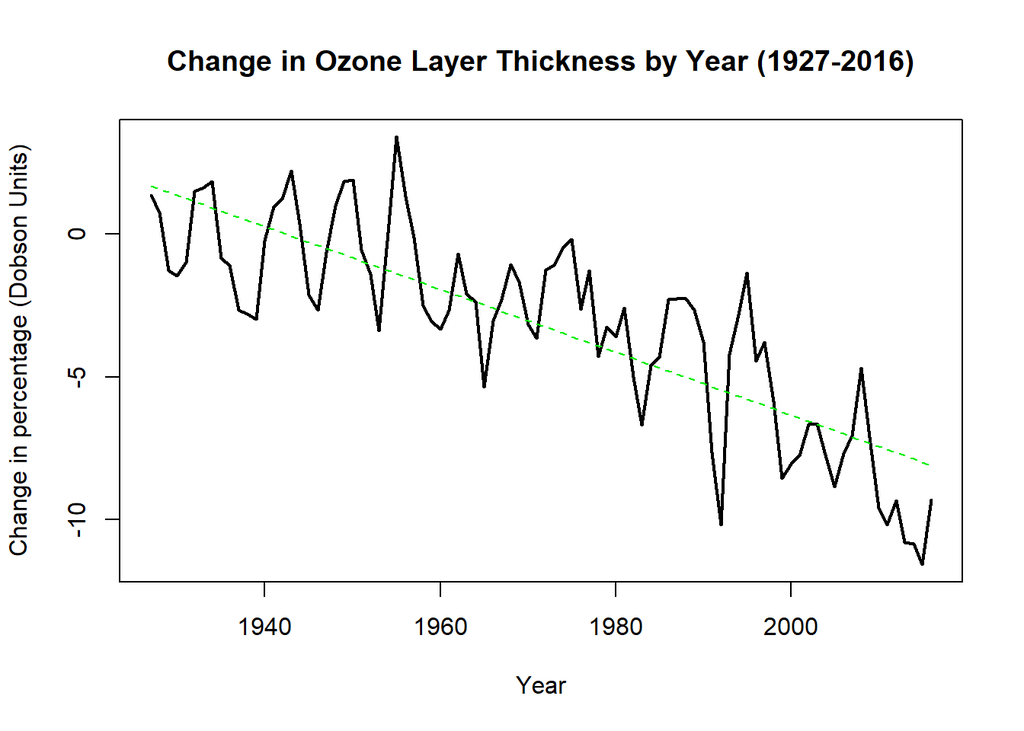

```r
# Visualise data with the linear model overlay
plot(
  data_ts,
  lwd = 2,
  xlab = 'Year',
  ylab = 'Change in percentage (Dobson Units)',
  main = 'Change in Ozone Layer Thickness by Year (1927-2016)'
)
lines(1927:2016, lin_model$fitted.values, col = 'green2', lty = 2)
```

Although the linear model seems to fit visually, it would be unqise to take it for face value.

Here I will investigate the residuals of the linear model. First with the normality of residuals with a Q-Q plot.

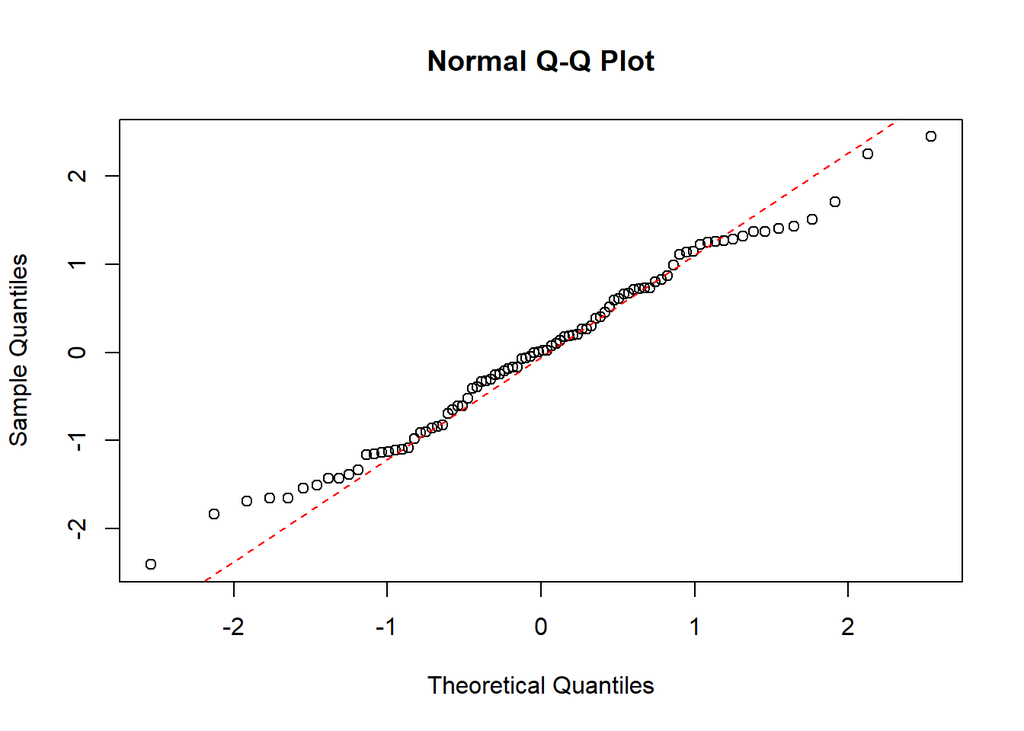

```r
rlin <- rstudent(lin_model)

qqnorm(rlin)
qqline(rlin, col = 'red', lty = 2)
```

There is evidence of some deviation from the quantile-quantile line at the ends of the quantiles. This interferes with any confidence in stating the standardised residuals are completely normal. SO we shallrefine our investigation.

A histogram will further demonstrate possible normality of residuals.

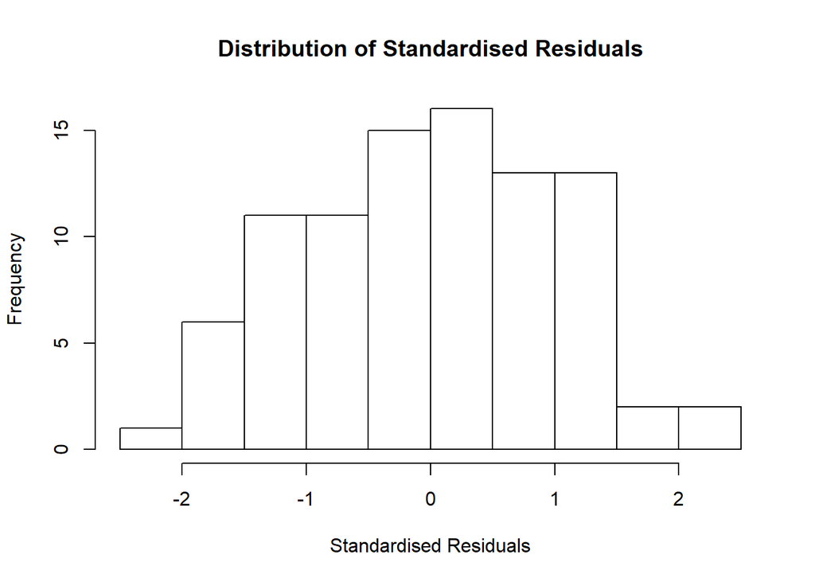

```r
hist(rlin,
     breaks = 10,
     xlab = 'Standardised Residuals',
     main = 'Distribution of Standardised Residuals')
```

The histogram here shows further evidence of normality of residuals.

A Shapiro-Wilks test will finalise the significance of normality present in the standardised residuals of the fitted linear model.

```r
shapiro.test(rlin)
```

```
##
##  Shapiro-Wilk normality test
##
## data:  rlin
## W = 0.98733, p-value = 0.5372
```

Now that normality is deemed to be significant in the residuals, we can look at their behavior over time.

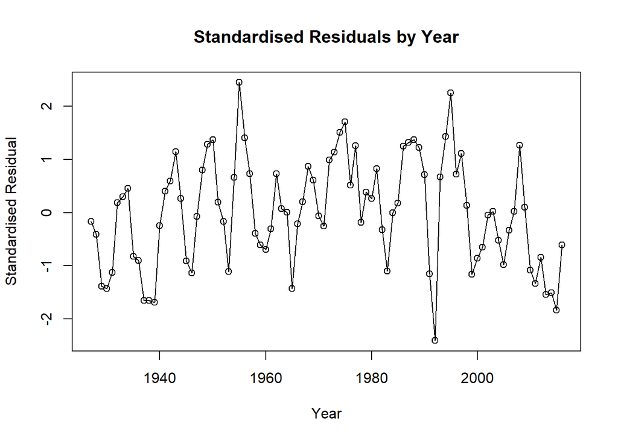

```r
# residuals
plot(y = rlin,
     x = as.vector(time(data_ts)),
     type = 'o',
     xlab = 'Year',
     ylab = 'Standardised Residual',
     main = 'Standardised Residuals by Year')
```

The graph shows some major deviations, but not completly adherent to white noise. There also seems to be a slight polynomial trend present in the residuals, something not being captured by the linear model.

The autocorrelation function will show any significant correlations at sequential lags.

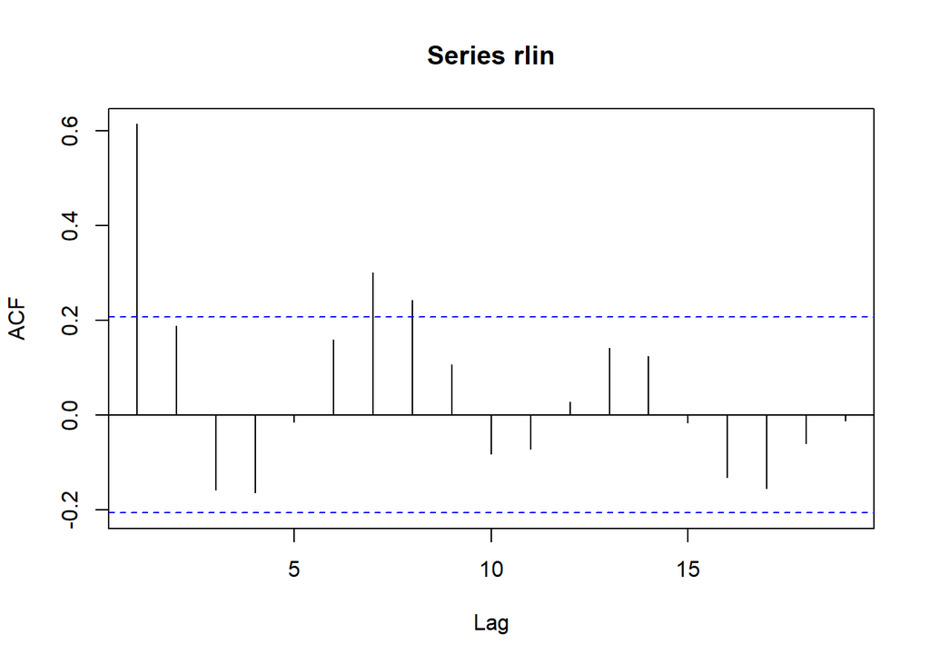

```r
acf(rlin)
```

We conclude that a linear model is not capturing multiple facets of the time series, and thus is not a suitable model for forecasting predictions.

Due to the residual plot over time demonstrating a polynomial characteristic in the residuals, I will attempt to fit and evaluate a quadractic model.

```r
# fit a quadratic regression model
t <- time(data_ts)
t2 <- t ^ 2
quad_model <- lm(data_ts ~ t + t2)
summary(quad_model) # all stat sig
```

```
##
## Call:
## lm(formula = data_ts ~ t + t2)
##
## Residuals:
##     Min      1Q  Median      3Q     Max
## -5.1062 -1.2846 -0.0055  1.3379  4.2325
##
## Coefficients:
##               Estimate Std. Error t value Pr(>|t|)
## (Intercept) -5.733e+03  1.232e+03  -4.654 1.16e-05 ***
## t            5.924e+00  1.250e+00   4.739 8.30e-06 ***
## t2          -1.530e-03  3.170e-04  -4.827 5.87e-06 ***
## ---
## Signif. codes:  0 '***' 0.001 '**' 0.01 '*' 0.05 '.' 0.1 ' ' 1
##
## Residual standard error: 1.815 on 87 degrees of freedom
## Multiple R-squared:  0.7391, Adjusted R-squared:  0.7331
## F-statistic: 123.3 on 2 and 87 DF,  p-value: < 2.2e-16
```

```r
# R^2: 0.74 higher than a linear model
```

Here we can see an R squared value of 0.7391, meaning 73.91% of variation in the data is explained by this model. This is an improvement upon the linear model which had an R squared value of 0.6693. All deemed coefficients statistically significant with p values < 0.001.

Given the improvement upon the R squared valued, we will visualise the fit of the quadratic model over the original time series data.

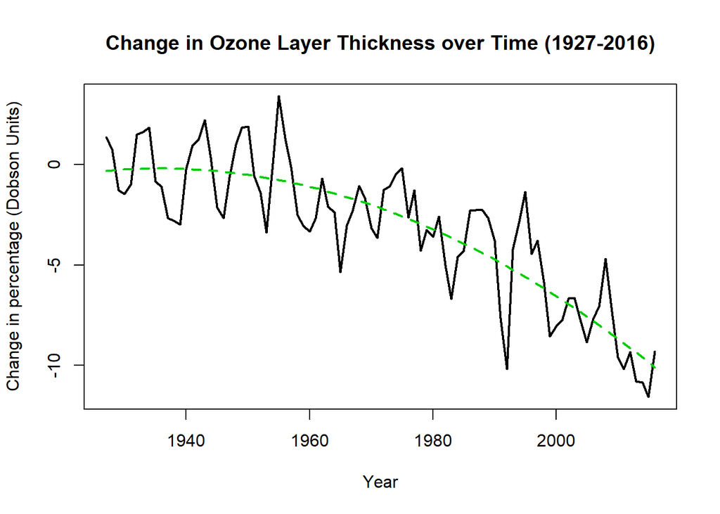

```r
# Visualise time series and quadratic model
plot(
  data_ts,
  lwd = 2,
  xlab = 'Year',
  ylab = 'Change in percentage (Dobson Units)',
  main = 'Change in Ozone Layer Thickness over Time (1927-2016)'
)
# Overlay quadratic model
years <- seq(1927, 2016, 1)
lines(years, quad_model$fitted.values, col = 'green3', lty = 2, lwd = 2)
```

The plot seems to capture the quadratic trend, but of course we will further investigate the residuals of the model to dictate the significance of the fitted model.

First we shall inspect the normality of the standardised residuals with a Q-Q plot.

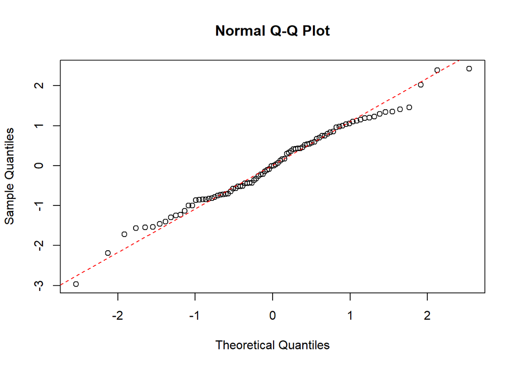

```r
# validate model (all p-values below significance level of 0.05, but check assumptions)
rquad <- rstudent(quad_model) # grab standardised residuals
qqnorm(rquad) # create quantile quantile plot
qqline(rquad, col = 'red', lty = 2) # some deviation from the quantile-quantile line at the ends of the distrubition
```

The standardised residuals of the quadratic model tend to deviate at the end quantiles, but to a lesser degree than the linear model.

We can further investigate the distribution of the residuals with a histogram.

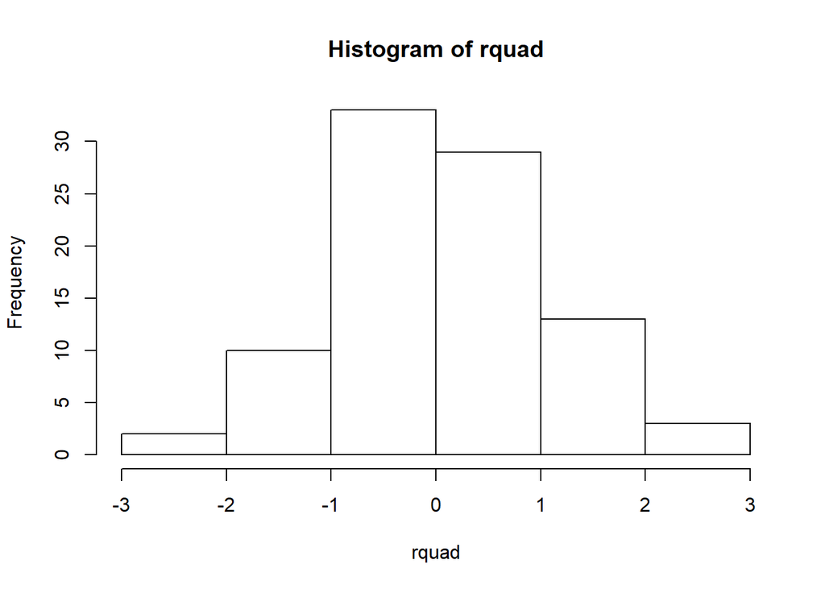

```r
hist(rquad, breaks = 6) # plot histogram
```

The distribution of the standardised residuals of the quadratic model seems to follow a normal distribution. A Shapiro-Wilks test will statistically validate that claim.

```r
shapiro.test(rquad) # fail to reject, assume normality, closer to 1 than lin model
```

```
##
##  Shapiro-Wilk normality test
##
## data:  rquad
## W = 0.98889, p-value = 0.6493
```

Now that normality has been demonstrated in the standardised residuals, we move on to inspecting for trends in the standardised residuals with a standard plot.

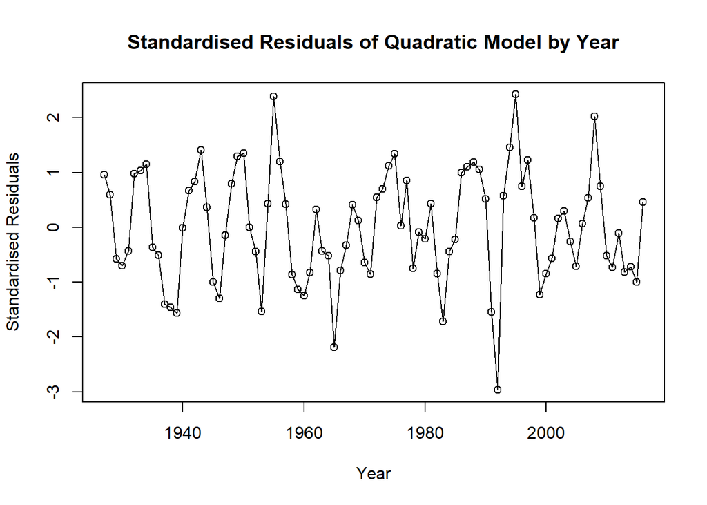

```r
# residuals
plot(y = rquad,
     x = as.vector(time(data_ts)),
     type = 'o',
     xlab = 'Year',
     ylab = 'Standardised Residuals',
     main = 'Standardised Residuals of Quadratic Model by Year')
```

```r
# some major deviations, but not completly dissimilar to white noise
```

The plot demonstrates some slight changes in variance, circa 1960 to 1985 has a lesser variance compared to the decades either side, although the average seems to be stationary we cannot state this has stationary behavior due to the changes in variance. A noteworthy issue with this plot is that a cyclical/seasonal trend is present in the residuals, suggesting that a harmonic parameter is not being captured by the quadratic model. We can further investigate the standardised residuals with an autocorrelation function to show significant autocorrelations at sequential lags.

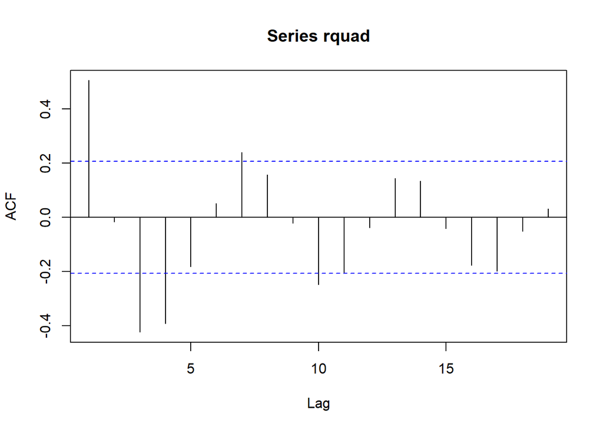

```r
acf(rquad) # at lags 1, 3, 4, 7... many intercepts THROW MODEL, also the residuals of this model are harmonic
```

The ACF clearly demonstrates intercepts of the thresholds and also shows a pattern indicating the quadractic model does not capture all behavioral aspects of the time series data. The first lag shows an autocorrelation value of ~0.5, which is an again an improvement upon the linear model which held an autocrrelation at the first lag of ~0.6.

Due to the patterns in the residual plots and ACF, I will create a harmonic and quadratic model and test its parameters against the quadratic model, if improves upon the new model can be shown then I will forecast the following 5 years with the new harmonic quadractic model.

In order to create a harmonic based model, I need to look for the most suitable frequency value of the time series data. Here I wrote a loop to determine the most statistcally significant frequency values, as we need to reconvert the original data to a time series with the frequency argument.

```r
# Create empty vector to fill with loop results for Cosine waves
mod_sum_vec <- vector()
# Create loop
for (i in 3:100) {
  data_freq <- ts(dataset, frequency = i)
  har <- harmonic(data_freq, 1)
  t <- time(data_freq)
  t2 <- t^2
  quad_har_model <- lm(data_freq ~ t + t2 + har[,1]) # Fit quadratic harmonic model with only the sine parameter
  mod_sum_vec[i] <- summary(quad_har_model)$coefficients[,4][4] # Grab the pvalue for each iteration
}

# Create dataframe with frequency column matched to p-values
library(dplyr)
df <- data_frame(freq = 1:length(mod_sum_vec),
                 pval_cos = mod_sum_vec)
```

```r
# Create empty vector to fill with loop results for Sine waves
mod_sum_vec <- vector()
# Create loop
for (i in 3:100) {
  data_freq <- ts(dataset, frequency = i)
  har <- harmonic(data_freq, 1)
  t <- time(data_freq)
  t2 <- t^2
  quad_har_model <- lm(data_freq ~ t + t2 + har[,2]) # Fit quadratic harmonic model with only the sine parameter
  mod_sum_vec[i] <- summary(quad_har_model)$coefficients[,4][4] # Grab the pvalue for each iteration
}
```

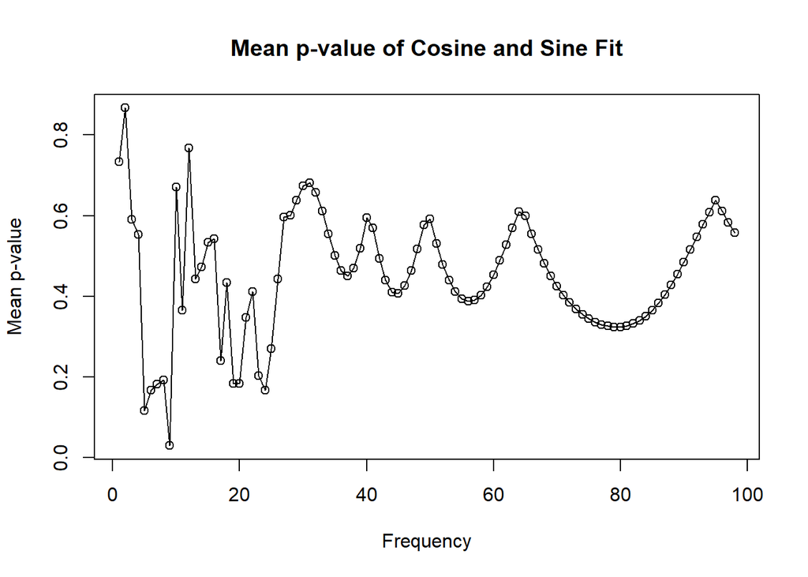

```r
# Create dataframe with frequency column matched to p-values
library(dplyr)
df <- cbind(df, mod_sum_vec) # Combine p-values of cos and sin
colnames(df) <- c('Freq','Pval_Cos','Pval_Sin')
df <- df[complete.cases(df),]
df <- df %>%  mutate(Mean_Pval = (Pval_Cos + Pval_Sin)/2)

# Visualse average of p-values
plot(df$Mean_Pval, type = 'o', main = 'Mean p-value of Cosine and Sine Fit', xlab = 'Frequency',ylab = 'Mean p-value')
```

```r
# Find minimum pair of p-values
df[min(df$Mean_Pval) == df$Mean_Pval,]
```

```
##   Freq   Pval_Cos   Pval_Sin  Mean_Pval
## 9   11 0.01663375 0.04333215 0.02998295
```

```r
# Freq = 11
```

As shown up the plot and the minimum value found, frequency should be set to 11 to determine the most statistcally significant coefficients in regard to a harmonic fit.

Below I create the harmonic quadratic model with frequency of time series data set to 11.

```r
#### CREATE HARMONIC/QUADRATIC MODEL
data_ts_11 <- ts(dataset, frequency = 11)
t <- time(data_ts_11) # determine quadratic variables
t2 <- t^2
t3 <- cos(2*pi*t) # determine harmonic variables
t4 <- sin(2*pi*t)

mod_11 <- lm(data_ts_11 ~ t + t2 + t3 + t4)
summary(mod_11)
```

```
##
## Call:
## lm(formula = data_ts_11 ~ t + t2 + t3 + t4)
##
## Residuals:
##     Min      1Q  Median      3Q     Max
## -4.5918 -1.2351  0.0611  1.2529  3.9525
##
## Coefficients:
##             Estimate Std. Error t value Pr(>|t|)
## (Intercept) -0.74955    0.84734  -0.885   0.3789
## t            0.62291    0.37805   1.648   0.1031
## t2          -0.17999    0.03667  -4.908 4.38e-06 ***
## t3          -0.64550    0.25678  -2.514   0.0138 *
## t4           0.55759    0.26078   2.138   0.0354 *
## ---
## Signif. codes:  0 '***' 0.001 '**' 0.01 '*' 0.05 '.' 0.1 ' ' 1
##
## Residual standard error: 1.73 on 85 degrees of freedom
## Multiple R-squared:  0.7685, Adjusted R-squared:  0.7576
## F-statistic: 70.55 on 4 and 85 DF,  p-value: < 2.2e-16
```

```r
# Check without t variable
mod_11v2 <- lm(data_ts_11 ~ t2 + t3 + t4)
summary(mod_11v2) # lower R squared, go with original Harmonic Quadratic model
```

```
##
## Call:
## lm(formula = data_ts_11 ~ t2 + t3 + t4)
##
## Residuals:
##     Min      1Q  Median      3Q     Max
## -4.3222 -1.2116  0.0192  1.3870  4.0941
##
## Coefficients:
##              Estimate Std. Error t value Pr(>|t|)
## (Intercept)  0.558682   0.298914   1.869   0.0650 .
## t2          -0.120846   0.007588 -15.927   <2e-16 ***
## t3          -0.674602   0.258714  -2.608   0.0108 *
## t4           0.541686   0.263190   2.058   0.0426 *
## ---
## Signif. codes:  0 '***' 0.001 '**' 0.01 '*' 0.05 '.' 0.1 ' ' 1
##
## Residual standard error: 1.747 on 86 degrees of freedom
## Multiple R-squared:  0.7611, Adjusted R-squared:  0.7528
## F-statistic: 91.33 on 3 and 86 DF,  p-value: < 2.2e-16
```

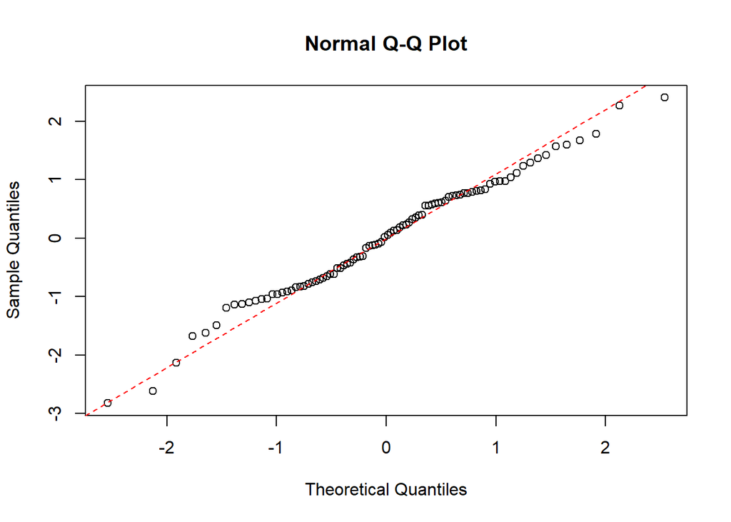

```r
rquad_har <- rstudent(mod_11) # grab standardised residuals
qqnorm(rquad_har) # plot QQ plot
qqline(rquad_har, col = 'red', lty = 2) # plot normal distribution line
```

### does not deviate from line, test stat sig with shap wilks

```r
shapiro.test(rquad_har)
```

```
##
##  Shapiro-Wilk normality test
##
## data:  rquad_har
## W = 0.98801, p-value = 0.5855
```

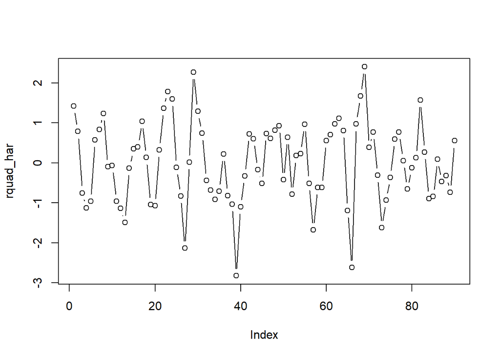

```r
plot(rquad_har, type = 'b')
```

### still some harmonic pattern not being captures, but the mean looks stationary despite the variance changing slightly, not white noise, look at acf

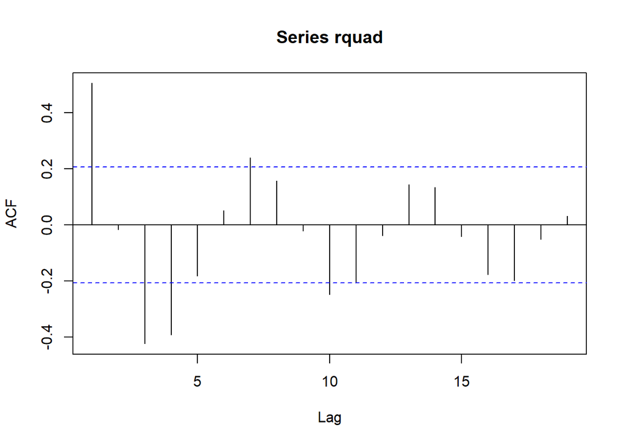

```r
acf(rquad) # still a ~0.5 signif at lag 1, a clearly a trend in the pattern
```

### similar trend pattern as quad mod, lag 1 same autocor value, but a higher R squared demonstrates the better of the 2 models, now predict for forecasting and then visualise

```r
### PREDICT HARMONIC
freq <- 11 # set freq of ts

interval <- 1/freq # find the interval values

h <- 5 # set prediction

t_last <- t[length(t)] # find last value

t_new <- seq((t_last + interval), (t_last + interval * h), by = interval) #

t <- t_new
t2 <- t^2
t3 <- cos(2*pi*t)
t4 <- sin(2*pi*t)

new_t_df <- data.frame(t, t2, t3, t4)

predt <- predict(mod_11, new_t_df, interval = 'prediction')
```

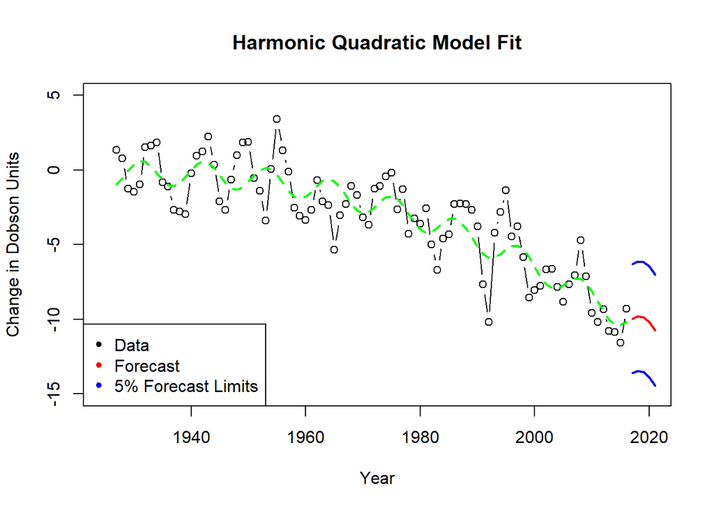

```r
### VISUALISING MODEL AND FORECAST
plot(ts(data_ts_11, start = 1927), type = 'b', xlim = c(1925,2020), ylim = c(-15,5), lwd = 1, xlab = 'Year', ylab = 'Change in Dobson Units', main = 'Harmonic Quadratic Model Fit' )
lines(ts(mod_11$fitted.values, start = 1927), col = 'green', lwd = 2, lty = 2)
lines(ts(as.vector(predt[,1]), start = 2017), col = 'red', lwd = 2, lty = 1)
lines(ts(as.vector(predt[,2]), start = 2017), col = 'blue', lwd = 2, lty = 1)
lines(ts(as.vector(predt[,3]), start = 2017), col = 'blue', lwd = 2, lty = 1)
legend('bottomleft',col = c('black','red','blue'), legend = c('Data','Forecast','5% Forecast Limits'), pch = 20)
```

Summary

A lin, quad and harm/quad walk into a bar, the harm/quad was the best one in regard to the some of the parameters, but none of them are actually valid time series models due to the plotting of res and acf lag intercepts.